# A Microscopic Journey Through the Human Body

Why your tongue and your hands don’t share the same microbial universe

microbiome

QIIME2

16S rRNA

diversity

R

Shiny

Metagenomic analysis of the Moving Pictures dataset: microbial diversity across four body sites, with an interactive results explorer.

Author

Mikrobiota con K

Published

May 15, 2026

16S rRNA · V4 QIIME2 α/β Diversity Longitudinal Interactive App

If we could shrink down to the size of a bacterium and explore the human body like microscopic adventurers, we would discover something no biology textbook quite captures: **every part of the body is a different planet**.

The tongue looks nothing like the skin. The palm of your hand looks nothing like the gut. And every corner of the body selects, with brutal precision, who gets to live there.

In microbiology, this has a name: **microbial diversity**. And when we measure it with high-throughput sequencing, the human body stops looking like a uniform organism and becomes something far more interesting:

A planet full of microscopic habitats, each with its own rules, its own inhabitants, and its own ecological logic.

## 🌍 The body as a collection of ecosystems

Think about the difference between a desert and a tropical rainforest. Both are on the same planet, but they have different humidity, different temperature, different nutrients — and completely different organisms adapted to each environment.

The exact same thing happens inside you.

The **skin of your hands** is a relatively dry environment, exposed to air, soap, and constant temperature changes. A hostile habitat where only the most resilient survive — mainly bacteria from the phyla *Actinobacteriota* and *Proteobacteria*, adapted to arid conditions and high environmental exposure.

The **tongue**, by contrast, is another story entirely. Constant moisture, available nutrients, stable temperature, saliva, food remnants and millions of chemical interactions every minute. Microbiologically speaking, it is a true tropical rainforest — dominated by *Firmicutes* and with a proportion of *Fusobacteriota* you won’t find anywhere else in the body.

And the **gut** — that great unknown — operates under its own rules: an anaerobic ecosystem where *Firmicutes* and *Bacteroidota* maintain a constant balance that affects everything from digestion to immune response.

## 🔬 How we measure the invisible

To quantify these differences we use high-throughput sequencing of the **16S rRNA gene** (V4 region), the standard molecular marker in microbiome studies. This gene acts as a biological barcode: each group of bacteria has a slightly different version, which allows us to identify them without needing to culture them in the lab.

The analysis pipeline followed the standard **QIIME2** workflow:

Paired-end import → DADA2 denoising → 770 ASVs → Silva 138 classification → Rarefaction 1,080 reads → α / β diversity in R

The **DADA2** step is critical: instead of clustering sequences into OTUs at 97% similarity (the classic method), it infers **exact amplicon sequence variants** (ASVs), resolving single-nucleotide differences. This significantly reduces false positives and enables cross-study comparisons without losing taxonomic resolution.

**Rarefaction to 1,080 reads** normalises sequencing depth across samples — a necessary step to ensure that the diversity differences we observe are biological, not an artefact of how many reads each sample generated.

## 📊 What we found: a different world at every body site

The starting question was simple: do all body areas harbour similar microbial communities? The short answer is **no**. The long answer is far more interesting.

Samples analysed 34 2 subjects × 4 sites × time

Unique ASVs 770 After DADA2 denoising

Variance explained 68% PERMANOVA · body site

Shannon mouth vs skin +78% Higher diversity in tongue

The most striking difference appears when calculating **alpha diversity** — a measure of how many distinct species coexist in a single sample and how evenly they are distributed. The Shannon index for the oral cavity (~3.5) exceeds that of the palms (~2.0) by almost 80%. But that is only the beginning.

The key finding worth highlighting: **the individual subject explains only 9%**.

In other words: the microbiome of your mouth resembles the mouth of a stranger more than it resembles your own gut. We are more predictable as a habitat than as individuals.

**Body site matters more than the person.** Anatomy imposes such restrictive physicochemical conditions that microbial selection converges across different individuals — regardless of their genetics, diet or lifestyle.

## ⏱️ The microbiome over time: stable or chaotic?

This study has a dimension that cross-sectional analyses cannot capture: **longitudinal follow-up**. Both subjects were sampled over several months, making it possible to observe how their microbiome evolves over time.

The gut shows a particularly interesting pattern: despite daily perturbations — dietary changes, stress, environmental variation — diversity fluctuates but tends to recover an individual-specific baseline level. This phenomenon is known as **microbial resilience**, and it is one of the most important concepts in human microbiome ecology.

We also observed the effect of **antibiotic use**, recorded in the study metadata. Samples collected during antibiotic treatment show sharp drops in diversity — a clear ecological perturbation that, in most cases, the system manages to reverse.

## 👅 The mouth: a microscopic coral reef

The oral cavity deserves special mention. It is not simply “a moist surface” — it is one of the densest and most dynamic microbial ecosystems in the body, where bacteria cooperate, compete, form biofilms and exchange genes.

Every meal temporarily alters that environment. Every drink changes the pH. Every brushing partially reshuffles the community. And yet the ecosystem manages to remain relatively stable. The characteristic presence of *Fusobacteriota* — a phylum virtually absent from skin and gut — is such a clear taxonomic marker that it can identify oral samples from a single look at phylum-level composition.

## 🧠 Why going beyond “there are bacteria here” matters

The microbiota is no longer studied as a biological curiosity. We know it influences inflammation, metabolism, immunity and infection. But to understand that role we first need to answer more basic questions: where are they? how many are there? how do they change? what perturbs them?

This type of analysis — alpha diversity, beta diversity, taxonomic composition, longitudinal follow-up, effect of covariates such as antibiotic use — is the foundation on which more complex clinical studies are built. Without this scaffolding, correlations between the microbiome and disease lack the ecological context to stand on.

## 🔍 Explore it yourself

The text tells the story. But the data speak for themselves.

In the interactive explorer below you can reproduce the analyses, change parameters and see how the conclusions shift:

- **Which diversity index** — Shannon, Simpson, Faith PD — shows the strongest differences between sites?
- **How does PCoA separate** samples when you use UniFrac instead of Bray-Curtis?
- **Does diversity recover** after antibiotic use if you track it over time?

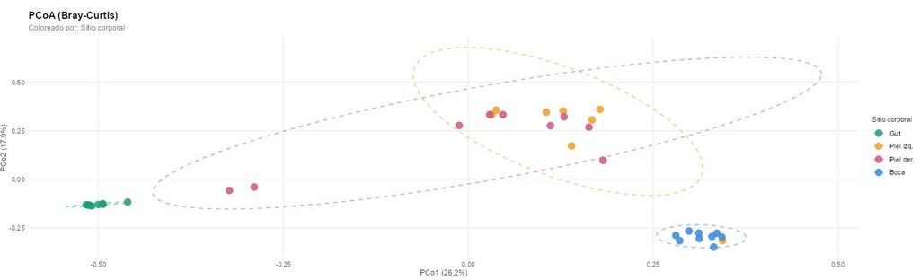

The interactive explorer lets you change the diversity index, distance metric, and filter by body site or antibiotic use — and see how the conclusions change in real time.

[🔍 Open interactive explorer](https://mikrobiotaconk.shinyapps.io/moving-pictures-app-v3/)

Opens in a new tab · Requires connection to Posit Connect

## ✨ One last thought

Perhaps the most powerful conclusion of this analysis is not statistical. It is conceptual.

The human body is not a single ecosystem. It is a collection of microscopic worlds coexisting simultaneously, each with its own selection rules, its own evolutionary history, and its own response to perturbations.

The next time you run your tongue over your teeth or rest your hand on a table, remember: billions of microorganisms just participated in an ecological interaction that happens constantly — and that we are only beginning to understand.

## References

Caporaso et al. (2011) Moving pictures of the human microbiome. *Genome Biology* 12:R50.

Bolyen et al. (2019) Reproducible microbiome data science using QIIME 2. *Nature Biotechnology.*

Callahan et al. (2016) DADA2: High-resolution sample inference from Illumina amplicon data. *Nature Methods.*

Quast et al. (2013) The SILVA ribosomal RNA gene database project. *Nucleic Acids Research.*